# Final Graphs

Erick Marchessault

21 May, 2020

# Packages and Data

```r
setwd("E:/Graphs May Term")
library(tidyverse)
library(patchwork)
```

```r
tickt <- read.csv("TickRType-graphs.csv")
tickt[is.na(tickt)] <- 0
tickt <- tickt %>%
  mutate(Site=factor(Site),
         Shade2=plyr::mapvalues(Shade,from="PS",to="YES"),
         OCC=ifelse(Amount<1,"NO","YES"))

tickwe <- read.csv("TickRWeather.csv")
tickwe[is.na(tickwe)] <- 0

TJ <- full_join(tickt,tickwe,by="ID") %>%
  mutate(Mowed2=plyr::mapvalues(Mowed,from=c("AM","MM","1/2M","PM","NM"),
                          to=c("All Mowed","All Mowed","Partially Mowed","Partially Mowed","Not Mowed")),
         Mowed2=factor(Mowed2,levels=c("All Mowed","Partially Mowed","Not Mowed")))

NewTJ <- TJ %>%
  FSA::filterD(Amount==1,Temp>0)

Tick <- read.csv("Tick.csv")

head(TJ)
head(NewTJ)
head(Tick)
```

In the summer of 2019, I started a research project with Professor Geoffrey Vincent at Northland College to test for Rocky Mountain Spotted Fever (RMSF) and Lyme disease in ticks at the Maxwell property in Ashland County Wisconsin. Many different data points were collected during the collection of ticks some of which are, temperature, wind speed, relative humidity, and many others. To collect the ticks, I used the blanket drag method which consists of dragging a blanket across the ground which the ticks attach to. We have yet to test the ticks for RMSF or Lyme disease because of a delay in the delivery of testing supplies. The collection and testing will be continued in the summer of 2020.

# Graph 1

```
#R> Warning: Removed 112 rows containing non-finite values (stat_bin).
```

```
#R> Warning: Removed 1 rows containing missing values (geom_label).
```

```
#R> Warning: Removed 1 rows containing missing values (geom_segment).
```

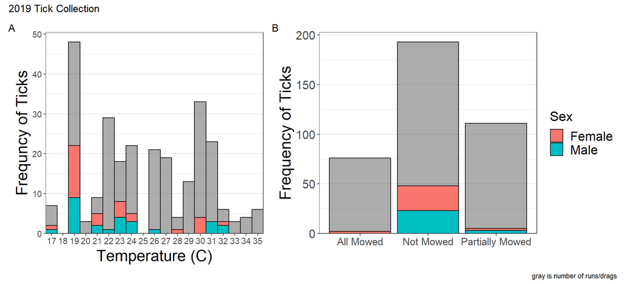

```r
A <- ggplot(data=NewTJ,mapping=aes(x=Temp)) +
  geom_histogram(data=TJ,mapping=aes(x=Temp),
                 alpha=0.5,
                 binwidth=1,
                 color="black") +
  geom_histogram(binwidth=1,
                 color="black",
                 aes(fill=Sex)) +
  scale_x_continuous(name = "Temperature (C)",
                     expand=expansion(mult=c(0,0)),
                     breaks=seq(15,35,1)) +
  scale_y_continuous(name="Frequncy of Ticks",
                     expand=expansion(mult=c(0,0.05))) +
  theme_bw() +
  theme(panel.grid.major.x=element_blank(),
        panel.grid.minor.x=element_blank(),
        legend.position = "none",
        axis.title = element_text(size=20),
        axis.text = element_text(size=11),
        panel.grid.major.y=element_line(color="gray90"),
        panel.grid.minor.y=element_line(color="gray90"))

B <- ggplot(data=NewTJ,mapping=aes(x=Mowed2)) +
  geom_bar(data=TJ,mapping=aes(x=Mowed2),
           alpha=0.5,
           color="black",
           stat="count") +
  geom_bar(stat="count",
           color="black",
           aes(fill=Sex)) +
  scale_x_discrete(name=element_blank()) +
  scale_y_continuous(name="Frequency of Ticks",
                     expand=expansion(mult=c(0,0.05))) +
  theme_bw() +
  theme(panel.grid.major.x=element_blank(),
        panel.grid.minor.x=element_blank(),
        legend.position = "none",
        axis.title = element_text(size=20),
        axis.text.y = element_text(size=15),
        axis.text.x = element_text(size=13),
        legend.title = element_text(size=17),
        legend.text = element_text(size=16),
        panel.grid.major.y=element_line(color="gray90"),
        panel.grid.minor.y=element_line(color="gray90"))+
  annotate(geom="label",
           y=100,x=NA,
           vjust="bottom"
           ,label="Mowed Data\nNot Collected") +
  annotate(geom="segment",
           x=NA,y=100,xend=NA,yend=49,
           arrow=arrow(length=unit(4,"mm"),
                       angle=15,type="closed"))

(A + B) +
  theme(legend.position="right") +
  plot_annotation(title="2019 Tick Collection",
                  tag_levels=c("A","B"),
                  caption="gray is number of runs/drags") +
  scale_fill_discrete(name = "Sex",
                      labels = c("Female","Male"))
```

With these two graphs I wanted to explore my data, by seeing if ticks prefer a certain temperature and grass setting. In Graph A we can see a large spike at 19 C, this was also the temperature that was present at the time of the most runs/drags. With only one year of collection it cannot be said confidently that ticks appear the most at 19 C, preliminary data from the 2020 data already has shown this not to be true, these results also might correlate with the average temperatures during Wisconsin’s “tick season”. In Graph B we can see a large spike in ticks in not mowed grass, this was also the setting that was most present during the time most runs/drags. This result is not surprising and only reaffirms the common knowledge that ticks are found in abundance in taller not mowed grass. The measurements for “All Mowed”, “Not Mowed”, and “Partially Mowed” grass setting was highly subjective and will not be a part of the 2020 data collection. Both graphs would be good to use for a public presentation or article on ticks in Ashland County Wisconsin.

# Graph 2

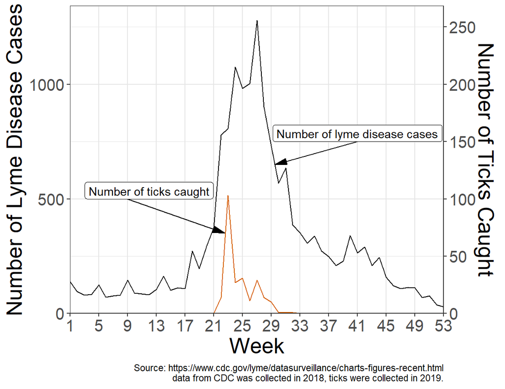

```r
ggplot(data=Tick,mapping=aes(x=Week)) +
  geom_density(stat="identity",
               aes(y=Cases)) +
  geom_density(stat="identity",
               aes(y=Caught*5),
               color="#D55E00") +
  scale_y_continuous(sec.axis = sec_axis(~./5,name = "Number of Ticks Caught"),
                     expand=expansion(mult=c(0,0.05))) +
  scale_x_continuous(breaks=seq(1,53,4),
                     limits=c(1,53),
                     expand=expansion(mult=c(0,0))) +
  labs(y="Number of Lyme Disease Cases",
       caption="Source: https://www.cdc.gov/lyme/datasurveillance/charts-figures-recent.html\ndata from CDC was collected in 2018, ticks were collected in 2019.") +
  theme_bw() +
  annotate(geom="segment",
           x=9,y=500,xend=22.5,yend=350,
           arrow=arrow(length=unit(4,"mm"),
                       angle=15,type="closed")) +
  annotate(geom="label",
           x=12,y=500,
           vjust="bottom",
           label="Number of ticks caught") +
  annotate(geom="segment",
           x=41,y=750,xend=29.5,yend=649.5,
           arrow=arrow(length=unit(4,"mm"),
                       angle=15,type="closed")) +
  annotate(geom="label",
           x=41,y=750,
           vjust="bottom",
           label="Number of lyme disease cases") +
  theme(axis.title = element_text(size=20),
        axis.text = element_text(size=15),
        panel.grid.major=element_line(color="gray90"),
        panel.grid.minor=element_line(color="gray90"),
        panel.grid.minor.x=element_blank())
```

With this graph I was hoping to see corresponding spikes between the two lines. If these two lines did have correlative spikes and the data were from the same year it could be theorized that because more ticks are present, people would be more likely to get Lyme disease. The reason the spikes would not be directly over each other is because of the latency of Lyme disease in the human body (~1 week to 6 months). I believe that the spike at about 23 weeks in the line labeled number of ticks caught would correspond to the spike at about 24 or 28 weeks on the line labeled number of Lyme disease cases, if the data was from the same year. It is very likely that we will see the same trend in the number of ticks caught in 2019 and 2020, the data collected in 2019 is probably a good indicator of what the 2018 data would have looked like, the only feature that will change in 2020 is the length of time the data is collected and will most likely cause the number of ticks line level off from weeks 17 to 24.